# LifeCycleSavings - CUONG VO - 131116

2023-11-14

## Dataset Desciption

Dataset is about the savings of personal based on disposable income in the 10 year period from 1960 to 1970

```r
summary(LifeCycleSavings)
```

```
##        sr             pop15           pop75            dpi
##  Min.   : 0.600   Min.   :21.44   Min.   :0.560   Min.   :  88.94
##  1st Qu.: 6.970   1st Qu.:26.21   1st Qu.:1.125   1st Qu.: 288.21
##  Median :10.510   Median :32.58   Median :2.175   Median : 695.66
##  Mean   : 9.671   Mean   :35.09   Mean   :2.293   Mean   :1106.76
##  3rd Qu.:12.617   3rd Qu.:44.06   3rd Qu.:3.325   3rd Qu.:1795.62
##  Max.   :21.100   Max.   :47.64   Max.   :4.700   Max.   :4001.89
##       ddpi
##  Min.   : 0.220
##  1st Qu.: 2.002
##  Median : 3.000
##  Mean   : 3.758
##  3rd Qu.: 4.478
##  Max.   :16.710
```

```r
str(LifeCycleSavings)
```

```
## 'data.frame':    50 obs. of  5 variables:
##  $ sr   : num  11.43 12.07 13.17 5.75 12.88 ...
##  $ pop15: num  29.4 23.3 23.8 41.9 42.2 ...
##  $ pop75: num  2.87 4.41 4.43 1.67 0.83 2.85 1.34 0.67 1.06 1.14 ...
##  $ dpi  : num  2330 1508 2108 189 728 ...
##  $ ddpi : num  2.87 3.93 3.82 0.22 4.56 2.43 2.67 6.51 3.08 2.8 ...
```

The dataset is in the structure of dataframe, with 5 columns about ratio of savings (divided by disposalbe income) (“sr”), % of population (“pop15”, “pop75”), disposable income (“dpi”) and change of disposable income (“ddpi”)

```r
mean(sr)
```

```
## [1] 9.671
```

```r
sd(sr)
```

```
## [1] 4.480407
```

For the savings ratio, the average amount in the population is 9.671 and the standard deviation is 4.4804069 and it’s told that, people tend to save around 9.671% their disposal income.

```r
cor(LifeCycleSavings[, c("sr","pop15", "pop75", "dpi", "ddpi")])
```

```
##               sr       pop15       pop75        dpi        ddpi
## sr     1.0000000 -0.45553809  0.31652112  0.2203589  0.30478716
## pop15 -0.4555381  1.00000000 -0.90847871 -0.7561881 -0.04782569
## pop75  0.3165211 -0.90847871  1.00000000  0.7869995  0.02532138
## dpi    0.2203589 -0.75618810  0.78699951  1.0000000 -0.12948552
## ddpi   0.3047872 -0.04782569  0.02532138 -0.1294855  1.00000000
```

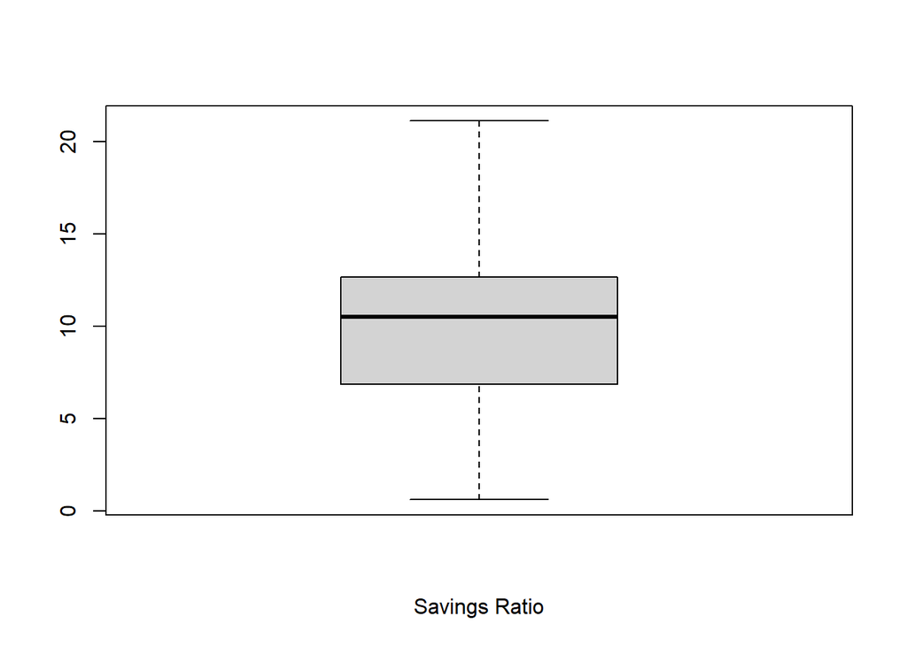

```r
boxplot(sr, xlab = 'Savings Ratio')
```

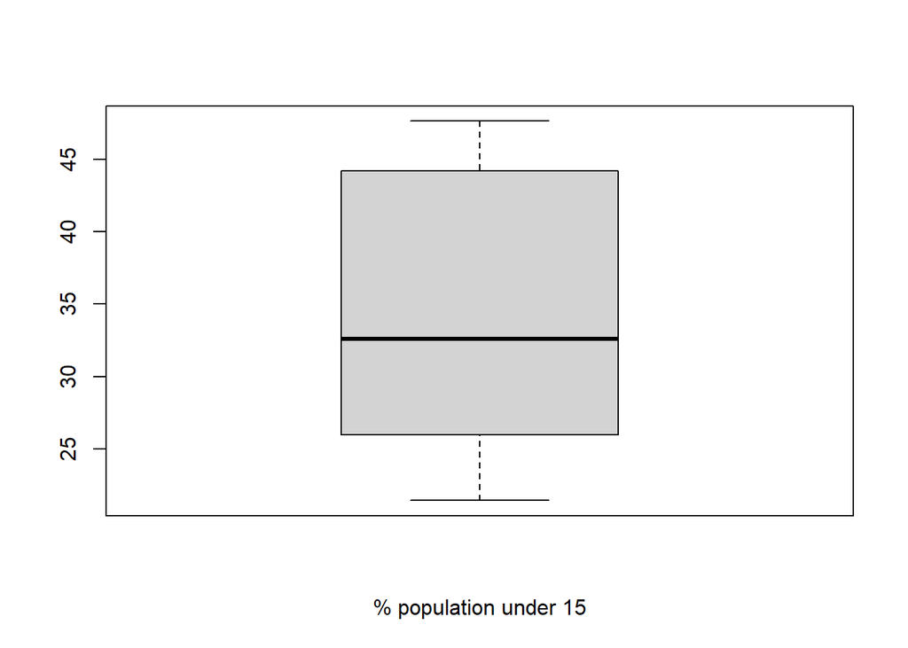

```r
boxplot(pop15, xlab = '% population under 15')
```

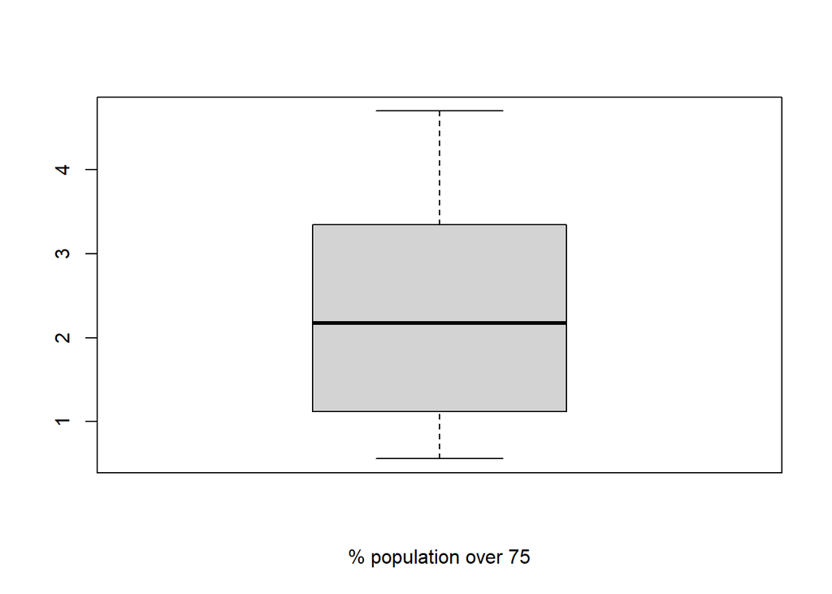

```r
boxplot(pop75, xlab = '% population over 75')
```

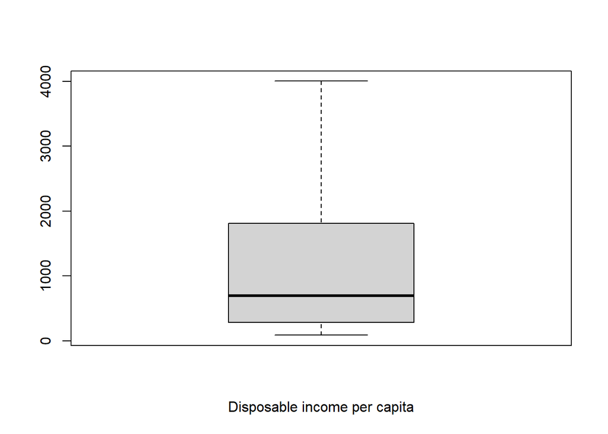

```r
boxplot(dpi, xlab = 'Disposable income per capita')
```

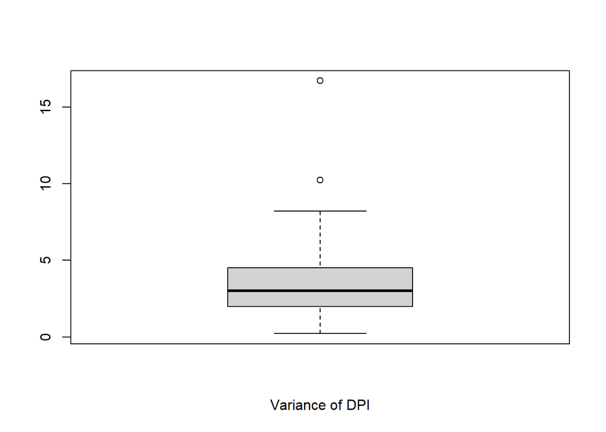

```r
boxplot(ddpi, xlab = 'Variance of DPI')
```

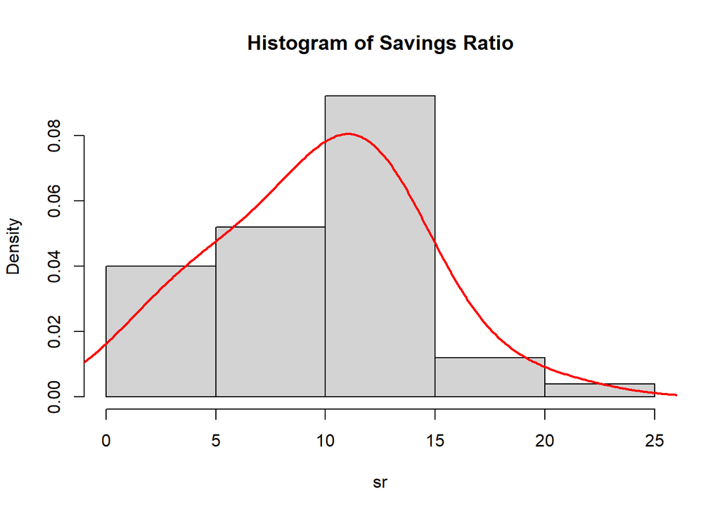

```r
hist(sr, main = 'Histogram of Savings Ratio', probability = TRUE)
lines(density(sr, adjust = 1.5), col = 'red', lwd = 2)
```

Base on the histogram, the histogram of the savings ratio, main the observation places from 0-15%

## Top N Analysis

```r
top10sr <- arrange(LifeCycleSavings, desc(sr)) %>% select('sr')
top10sr<- top10sr %>% top_n(10)
print(top10sr)
```

```
##                   sr
## Japan          21.10
## Zambia         18.56
## Denmark        16.85
## Malta          15.48
## Netherlands    14.65
## Italy          14.28
## Switzerland    14.13
## South Rhodesia 13.30
## Belgium        13.17
## Brazil         12.88
```

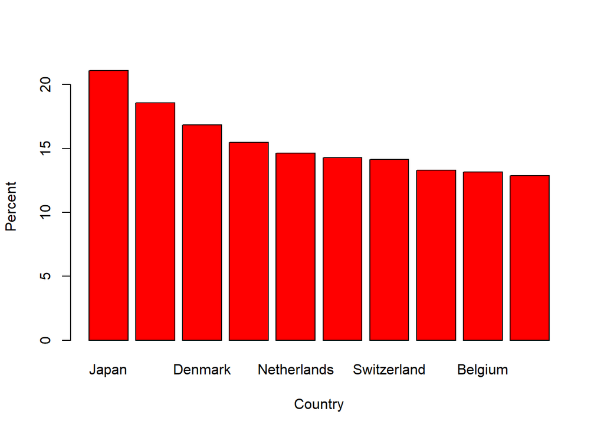

```r
barplot(top10sr$sr,
        names = row.names(top10sr),
        xlab = 'Country',
        ylab = 'Percent',
        col = if (top10sr$sr[1]) {'red'})
```

```r
top10dpi <- arrange(LifeCycleSavings, desc(dpi)) %>% select('dpi')
top10dpi<- top10dpi %>% top_n(10)
print(top10dpi)
```

```
##                   dpi
## United States 4001.89
## Sweden        3299.49
## Canada        2982.88
## Switzerland   2630.96
## Denmark       2496.53
## Germany       2457.12
## Luxembourg    2449.39
## Australia     2329.68
## Norway        2231.03
## France        2213.82
```

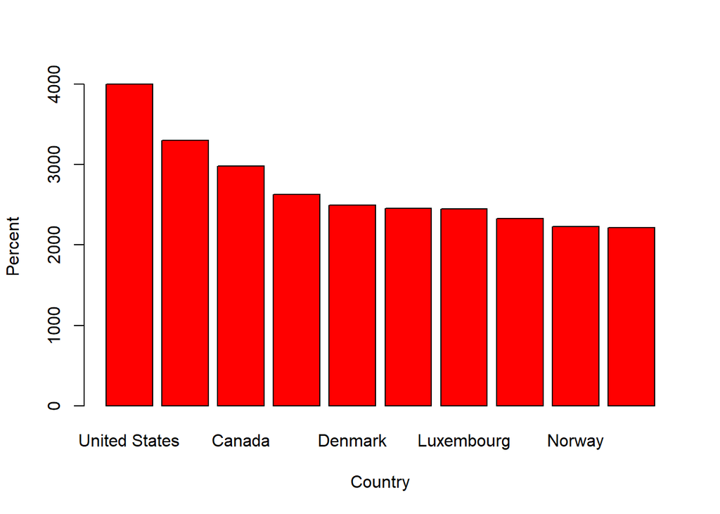

```r
barplot(top10dpi$dpi,
        names = row.names(top10dpi),
        xlab = 'Country',
        ylab = 'Percent',
        col = if (top10dpi$dpi[1]) {'red'})
```

As we can see *Japan* have the highest rate of savings in the population at *21.1%* but it seem like *Japan* is not the country have the highest disposable income per capita. Compared with the country which have the highest dpi, *United States* can not make it into top 10 country that have the highest savings rate.

## Correlation Analysis

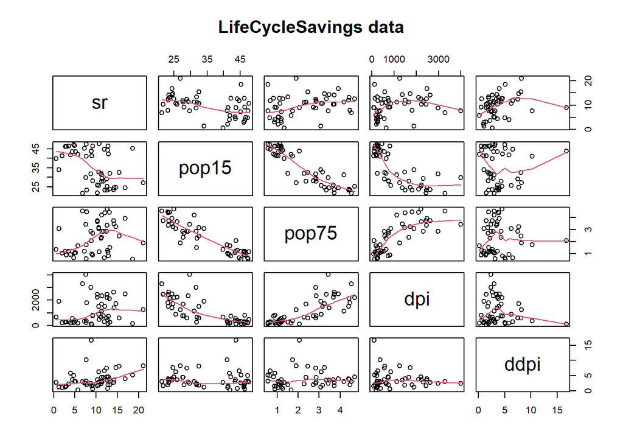

As we can see from correlation matrix, the saving ratio and % population under 15 is have negative correlation. Countries with young population tend to spend more instead of savings. However, the countries have old population tend to have higher savings ratio.